# respR - An R package for processing respirometry-related data

2017-09-24

## 1. Introduction

### 1.1 Installation

The stable version of `respR` is available on GitHub and (soon) CRAN (recommended).

```r
# CRAN
install.packages("respR")
#
# GitHub
# install.packages("devtools")  # run if devtools is not installed
devtools::install_github("januarharianto/respR")
```

### 1.2 Usage

When working with respirometry data, you will often need to:

1. Ensure that the data, or at least a subset of the data, is representative of the research question of interest.
2. Perform an initial analysis of the data to estimate the rate of change in oxygen concentration.
3. Correct for background changes in oxygen concentration, and then scale the result to the volume (of the medium) and mass (of the animal).

The `respR` package contains several functions to make these actions quick and easy:

- It provides quick visual feedbacks and diagnostic plots to help you subset and analyse your data.
- It uses computational techniques such as rolling regressions and kernel density estimates to estimate ranked maximum, minimum or best fit sections of the data.
- By separating the workflow into a series of connected functions, you can “mix and match” functions to help you achieve your result.

### 1.3 Functions

1. `check.input()` checks for structural errors and select individual data from multi-column datasets.
2. `calc.bg.rate()` calculates background changes in oxygen concentration.
3. `calc.rate()` calculates the rate of change of oxygen concentration over time in a data frame, or its subset.
4. `auto.rate()` automatically determines maximum, minimum, or “best fit” rate of change of DO over time.
5. `calc.mo2()` converts a number, or an object of class of `calc.rate`, to volume and/or weight-specific rates of change in oxygen concentration.

In addition, a few useful functions exist for specific data preparation and analysis scenarios:

7. `convert.do()` converts dissolved oxygen units (e.g. from % to mg/L).
8. `subsample.data()` thins a large dataset by sampling every *n* rows.
9. `pcrit()` calculates the breakpoint in metabolic rate, based on methods in Yeager and Ultsch (1989).

## 2. A typical workflow

To explore `respR` and its main functions we load the first example data, `urchin2013`. The dataset contains measurements of oxygen consumption in 16 individual sea urchins (*Heliocidaris erythrogramma*) and 2 “blank” measurements of background respiration (Harianto, *unpublished*). Detailed information about the data, including its source and methods, can be obtained with the command `?urchin2013`.

```r
library(respR)
data(urchin2013)
urchin2013
```

```
#> # A tibble: 271 x 19
#>    time.min     a     b     c     d     e     f     g     h     i     j
#>       <dbl> <dbl> <dbl> <dbl> <dbl> <dbl> <dbl> <dbl> <dbl> <dbl> <dbl>
#>  1      0.0  7.86  7.86  7.64  7.65  7.87  7.74  7.62  7.65  7.96  7.75
#>  2      0.2  7.87  7.79  7.60  7.71  7.87  7.72  7.61  7.66  7.97  7.72
#>  3      0.3  7.89  7.70  7.60  7.70  7.90  7.72  7.61  7.63  7.98  7.72
#>  4      0.5  7.90  7.68  7.60  7.72  7.92  7.74  7.62  7.66  7.97  7.72
#>  5      0.7  7.87  7.64  7.60  7.67  7.90  7.73  7.59  7.65  7.95  7.71
#>  6      0.8  7.82  7.69  7.61  7.61  7.88  7.70  7.60  7.65  7.94  7.70
#>  7      1.0  7.84  7.69  7.56  7.62  7.85  7.70  7.60  7.67  7.95  7.69
#>  8      1.2  7.84  7.66  7.59  7.63  7.83  7.69  7.60  7.69  7.96  7.70
#>  9      1.3  7.86  7.65  7.59  7.63  7.82  7.64  7.62  7.65  7.94  7.67
#> 10      1.5  7.81  7.64  7.59  7.57  7.85  7.64  7.61  7.66  7.96  7.66
#> # ... with 261 more rows, and 8 more variables: k <dbl>, l <dbl>, m <dbl>,
#> #   n <dbl>, o <dbl>, p <dbl>, b1 <dbl>, b2 <dbl>
```

### 2.1 Use `check.input()` to check for common errors

We first use `check.input` to scan the dataset for missing data, non-numeric data equal data lengths. Duplicate and unevenly-spaced data, specific to time, are also examined. Checks are performed on all columns in the data, regardless of data type:

```r
check.input(urchin2013)
```

[output not shown]

We can also subset a 2-column data frame from the dataset directly, by specifying the *x* and *y* arguments that correspond to columns in the data frame. The function will automatically identify the first column as time data, and the second column as oxygen concentration data. Error checks will be specific to the data types, and error messages are more informative (e.g. duplicates in time data will be called out).

With two-column data, `check.input()` will automatically remove NA data and produce a new data frame that we can use for subsequent analyses. A scatterplot of the data is produced automatically for quick visual inspection.

```r
u2 <- check.input(urchin2013, x = 1, y = 15)
```

```
#> n :  num [1:271] 7.61 7.61 7.65 7.67 7.62 7.61 7.62 7.64 7.64 7.62 ...
#> time.min :  num [1:271] 0 0.2 0.3 0.5 0.7 0.8 1 1.2 1.3 1.5 ...
#>                  time.min n
#> Length of data   271      271
#> Data are numeric
#> NA/NaN
#> Duplicates                X
#> Evenly-spaced    X        X
#> Warning: Time data is unevenly spaced. If using `calc.rate`, please avoid subsetting
#> by = 'row' unless you understand the range of data you are selecting using this method.
#> New dataframe generated.
```

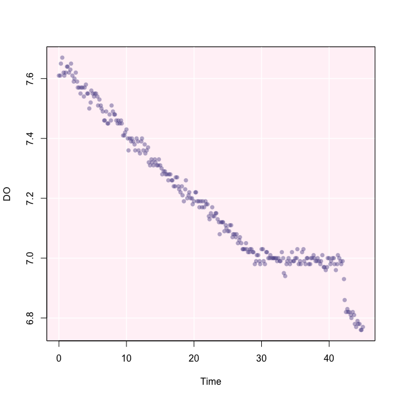

From the plot, non-linear irregularities in the data are evident. In this case, there is a change in the rate of oxygen uptake near the end of the timeseries (the sea urchin had climbed on top of the oxygen sensor, blocking it from surrounding water). A linear regression of the data frame would result in an underestimate of the true rate. We have several options to manage irregular, or non-linear portions of the data. For now, the data frame is saved as an object for later analysis.

**It should be noted that invoking `check.input` is optional** - the main functions in our package will readily accept any data frame as long as data are all numeric and error-free. Running `check.input` is a qualitative step that simply flags potential issues about the data before it is analysed.

### 2.2 Use `calc.bg.rate()` to process background rates for later use

The presence of microorganisms in the respirometry medium may be a potential source of significant experimental bias, and some users may want to account for background rates while running the main experiment. Since background rates typically account for a small percentage of experimental rates, these often-called “blank” experiments are routinely conducted alongside, or before and after main experiments, and the rates are averaged across several datasets to obtain a more accurate estimate of the correction.

The function `calc.bg.rate()` can be used to simultaneously process multiple background rate measurements as long as they share the time data. In `urchin2013`, background respiration was recorded and saved in columns 18 and 19. We analyse the data using `calc.bg.rate()` and save the output as an object.

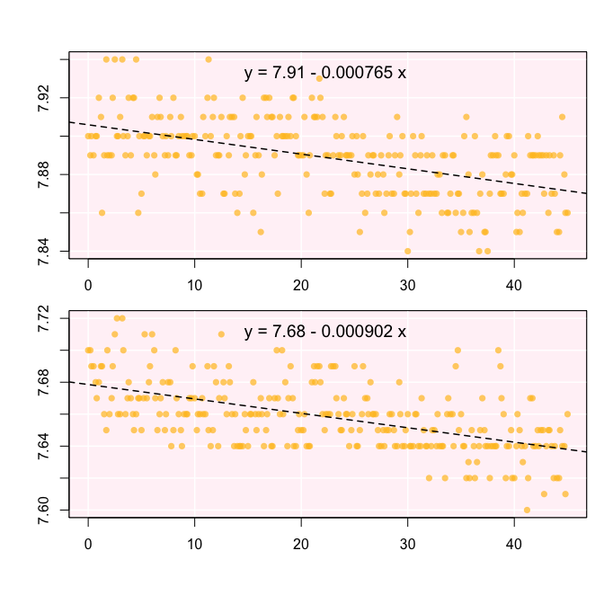

```r
ubg <- calc.bg.rate(urchin2013, xcol = 1, ycol = c(18:19), plot = T)
```

```r
print(ubg)
```

```
#> 2 regression(s) performed.
#>
#> Summary coefficients:
#>         b0            b1   rsq
#> 1 7.905921 -0.0007650013 0.248
#> 2 7.678558 -0.0009018607 0.303
#>
#> Average Rate: -0.000833
```

### 2.3 Use `calc.rate()` to perform the linear regression

Calling the function `calc.rate()` on a data frame, with no additional arguments, will prompt the function to perform a linear regression on the entire data frame.

```r
calc.rate(u2)
```

```
#> Data bounds not set. Performing analysis on entire data frame.
#> Data subset is by row.
```

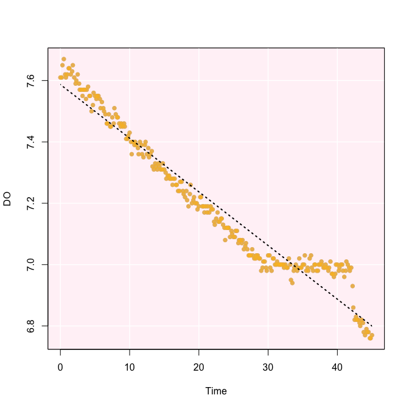

```
#> Rate (b1): -0.017492
```

In many cases, there is a need to truncate the data before rate could be determined, and the reasons for doing so may depend on the goal of the study being conducted. For example, a user may want to determine rate over an exact period of time, or only estimate the rate that is within a threshold of O<sub>2</sub> concentration. Equipment interference may also cause temporary irregularities or “spikes” in the data. We can work around the error and subset the regions that are not erroneous and still obtain valid results.

Based on the `from` and `to` arguments, a user may use `calc.rate` to truncate data in any of 4 ways:

1. Time period (`by = "time"`) - *“What is the average rate over a 25 minute period?”*
2. Total oxygen consumed/produced (`by = o2`) - *“At what rate is oxygen consumed between saturation points of 95% and 80%?”*
3. Proportion based on total oxygen consumed (`by = proportion`) - *“What is the rate from halfway down the data?”*
4. Precise subsetting by row for any other reason (`by = row`). - *“I’d like to subset between rows 11 and 273.”*

Here we subset the data by time, and include background respiration that had been saved by `calc.bg.rate`. Note that a user may also include background adjustments by including it as a number as long as the units match e.g. `background = 0.1`. Calling `summary()` shows a summary of data subset locations.

```r
u.rate <- calc.rate(u2, from = 4, to = 29, by = "time", bg = ubg)
```

```
#> Data subset is by time.
#> Background correction recognised and applied.
```

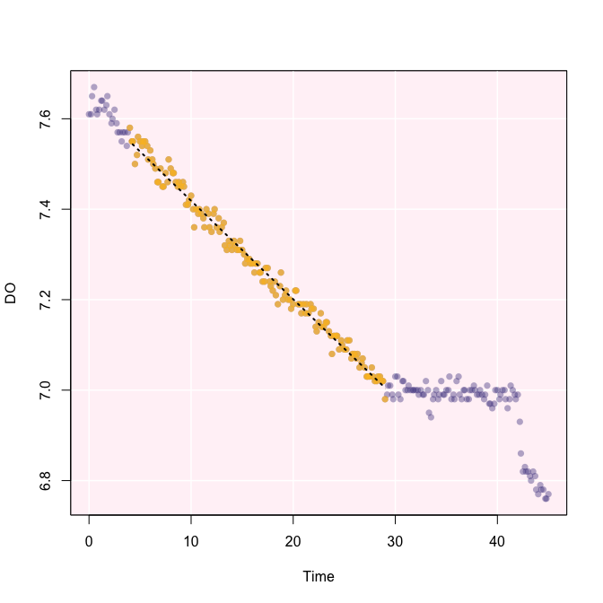

```r
print(u.rate)
```

```
#> Background (bg)  : -0.000833
#> Rate (b1)        : -0.021776
#> Adj. Rate (b1-bg): -0.020942
```

```r
summary(u.rate)
```

```
#>         b0          b1           bg       b1-bg   rsq from.row to.row
#> 1 7.636454 -0.02177588 -0.000833431 -0.02094245 0.987       25    175
#>   from.time to.time from.o2 to.o2 row.len time.len
#> 1         4      29    7.58  6.98     151       25
```

Plotting the output provides a series of diagnostic plots of the data subset that was analysed.

```
#> Plotting...this may take a while for large datasets.
```

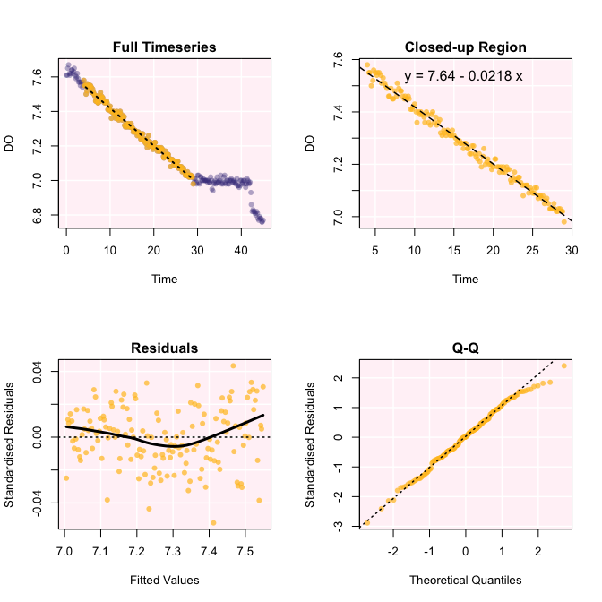

```r
plot(u.rate)
```

### 2.4 Use `calc.mo2()` to scale to volume- and/or mass-specific rates

Once the rate of change of oxygen has been determined, the user may either want to calculate:

1. O<sub>2</sub> consumed per unit time
2. mass-specific rate of change in O<sub>2</sub>

By specifying the relevant units and values in the function `calc.mo2()`, the user can obtain either output automatically.

For example, the user may convert the output of `calc.rate` to O<sub>2</sub> consumed over an hour:

```r
calc.mo2(u.rate, unit.in = "mg/l/s", unit.out = "mg/h", volume = 1.89)
```

```
#>         Input    Output
#> 1 -0.02177588 -142.4924
#>
#> Input unit : mg/L.o2/sec.time
#> Output unit: mg.o2/hour.time
```

Or, the user may convert a known rate to a volume-corrected, mass-specific rate:

```r
calc.mo2(u.rate, unit.in = "mg/l/s", unit.out = "mg/s/kg", volume = 1.89, mass = 0.13)
```

```
#>         Input    Output
#> 1 -0.02177588 -0.304471
#>
#> Input unit : mg/L.o2/sec.time
#> Output unit: mg.o2/sec.time/kg.mass
```

In either case, the conversion is applied as long as the input and output units are identified.

## 3. Reproducibility

We have ensured that any computational analysis performed by `respR` can be reproduced by another user. The main functions all produce an output list object which contains all the data and variables needed to re-analyse the results, within R or in other software. Individual objects in the list can be extracted using `$` for verification or further data manipulation, which include the original and subset data frames.

```r
# grab subset locations that were used to subset the main data frame:
u.rate$results
```

```
#>         b0          b1           bg       b1-bg   rsq from.row to.row
#> 1 7.636454 -0.02177588 -0.000833431 -0.02094245 0.987       25    175
#>   from.time to.time from.o2 to.o2 row.len time.len
#> 1         4      29    7.58  6.98     151       25
```

## 4. Further reading

This document introduces to you the basic methods of analysing respirometry data, but there are many other functions and user cases not explored. The following vignettes provide additional example workflows based on user needs, and may be useful to you:

1. Measuring intermittent data.
2. Maximum, minimum and interval analyses.
3. Pcrit setup and analyses

## 5. Code

```r
data(urchin2013)  # preload data
u2 <- check.input(df = urchin2013, x = 1, y = 15)  # subset the data and check its validity
ubg <- calc.bg.rate(urchin2013, timecol = 1, bgcol = c(18:19), plot = T) # calculate background rate
u.rate <- calc.rate(u2, from = 4, to = 29, by = "time", background = ubg)  # perform regression
plot(u.rate)  # view plot diagnostics of regression
# calculate mass-specific MO2, given known volume of container and mass of specimen:
calc.mo2(u.rate, unit.in = "mg/l/s", unit.out = "mg/s/kg", volume = 1.89, mass = 0.13)
```